# Hands_on_HOMEWORK_III

Marko Ludaic, Denis Expósito Navarro

Last update: 06 March, 2023

# Exercise 1

[Stamey et al. 1989](https://www.auajournals.org/doi/10.1016/S0022-5347%2817%2941175-X) examined the correlation between the level of prostate-specific antigen (PSA) and a number of clinical measures in men who were about to receive a radical prostatectomy. PSA is a protein that is produced by the prostate gland. The higher a man’s PSA level, the more likely it is that he has prostate cancer.  
Use the prostate cancer dataset, described here, to train a model that predicts log of prostate-specific antigen. The variables are

- log cancer volume (lcavol)
- log prostate weight (lweight)
- age
- log of the amount of benign prostatic hyperplasia (lbph)
- seminal vesicle invasion (svi)
- log of capsular penetration (lcp)
- Gleason score (gleason)
- percent of Gleason scores 4 or 5 (pgg45)

You can ignore column named “train” and do your own data splitting.  
Do not forget to perform feature selection!  
You can use as examples the [Linear Regression Lab](https://hastie.su.domains/ISLR2/Labs/Rmarkdown_Notebooks/Ch3-linreg-lab.html) and the section related to feature selection from [Lab: Linear Models and Regularization Methods](https://hastie.su.domains/ISLR2/Labs/Rmarkdown_Notebooks/Ch6-varselect-lab.html) from the book [An Introduction to Statistical Learning](https://www.statlearning.com/).

[output not shown]

[output cut: 83 more lines]

- We select 80% of the data to be used for training the model and the remaining 20% for testing it. Now we try to predict by doing a linear regression model with all our features:

```
##         4         5         8        11        16        20        21        24
## 0.7347089 1.8178570 2.1752966 1.5897562 1.9430235 1.8373427 2.0877782 2.6103426
##        31        32        34        50        53        59        65        67
## 2.1366407 1.9295270 1.4722093 2.1804505 2.2319391 2.2269538 2.6190075 3.0546135
##        68        87        88        89
## 3.0470558 3.0314330 2.9876451 4.3285181
```

```
## [1] 0.6432299
```

- We have to take into account that we need to do feature selection first, to reduce overfitting and improve our model. Our criteria will be having the maximum R-squared value (or Adjusted in our case), and the minimun BIC statistic, so we are going to determine how many features accomplish that:

```
## [1] 0.5371450 0.5906625 0.6313982 0.6379517 0.6463193 0.6516998 0.6549891
## [8] 0.6550936
```

```
## [1] 6
```

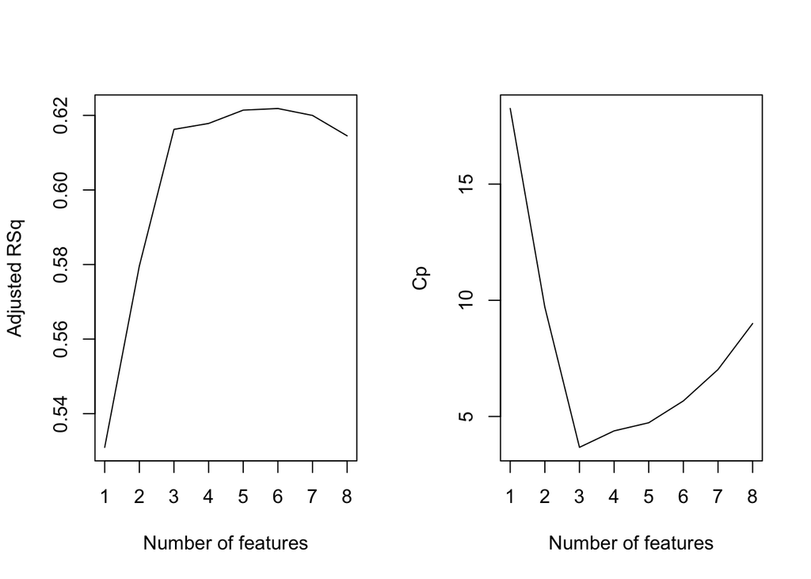

```
## [1] 3
```

```
## [1] 3
```

```
## (Intercept)      lcavol     lweight         svi
##  -0.6387308   0.5070009   0.6413619   0.6423961
```

```
##  (Intercept)       lcavol      lweight          age         lbph          svi
##  0.553796794  0.508246857  0.623766684 -0.019102557  0.081727054  0.591146702
##        pgg45
##  0.003598437
```

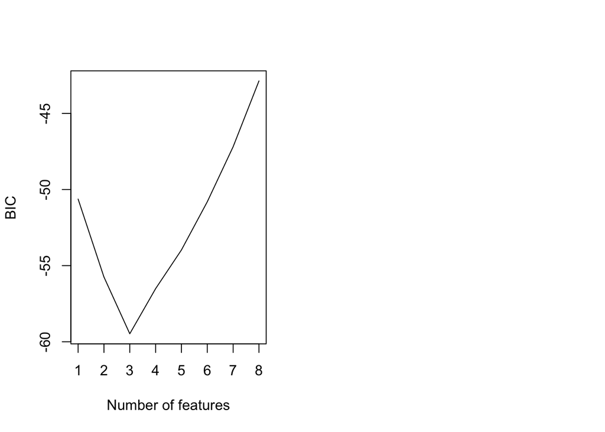

- We have two options, 3 or 6 features, so we will try both for building the linear regression model and see their accuracy on the predictions:

```
##         4         5         8        11        16        20        21        24
## 0.8563096 1.9436311 1.9828017 1.8019298 2.1058804 1.9071562 2.1360537 2.4783055
##        31        32        34        50        53        59        65        67
## 2.1291337 1.8937280 1.4620705 2.2686893 1.9517437 2.3159831 2.7360280 2.8743671
##        68        87        88        89
## 3.0739297 2.7809065 3.0423761 4.4530968
```

```
## [1] 0.6779363
```

```
##         4         5         8        11        16        20        21        24
## 0.7683298 1.7790453 2.1315698 1.5763952 1.8724018 1.8309457 2.0294978 2.6605841
##        31        32        34        50        53        59        65        67
## 2.1688057 1.9172007 1.4522794 2.1750468 2.2323133 2.2062766 2.5315296 3.0998406
##        68        87        88        89
## 3.0471109 2.9362981 2.9368300 4.3758001
```

```
## [1] 0.6503116
```

- Any of these number of features seemed to be better than our first attempt using all the variables, but in terms of RMSE this is not the case, so it could be that it is overfitting to the training data, and maybe the feature selection could not capture the complexity of the model (there could be some nonlinear relationships with some features, or that some important features were not included).

In any case, we propose the linear model with 6 features to avoid overfitting, as it the one with highest adjusted R-squared, so, based on the coefficients, we have:

```
##  (Intercept)       lcavol      lweight          age         lbph          svi
##  0.553796794  0.508246857  0.623766684 -0.019102557  0.081727054  0.591146702
##        pgg45
##  0.003598437
```

- Here we have the final model regression:

lpsa = 0.553796794 + 0.508246857(lcavol) + 0.623766684(lweight) - 0.019102557(age) + 0.081727054(lbph) + 0.591146702(svi) + 0.003598437(pgg45)

# Exercise 2

Use the breast cancer dataset to train a model that predicts whether a future tumor image (with unknown diagnosis) is a benign or malignant tumor. Try different machine learning algorithms such as:  
- KNNs  
- Decision trees  
- Random forest  
- Logistic Regression

The breast cancer dataset contains digitized breast cancer image features, and was created by [Dr. William H. Wolberg, W. Nick Street, and Olvi L. Mangasarian](https://archive.ics.uci.edu/ml/datasets/Breast+Cancer+Wisconsin+%28Diagnostic%29). Each row in the data set represents an image of a tumor sample, including the diagnosis (benign or malignant) and several other measurements (nucleus texture, perimeter, area, and more). Diagnosis for each image was conducted by physicians.

Do not forget to perform hyperparameter tuning!  
Which of all models performs better for this data? Discuss.

Generate a ROC curve for all the models.

You can use as a guide the analysis of this dataset included in the [chapter 5](https://datasciencebook.ca/classification1.html) of the Data Science, A First Introduction Book. Additionally, for further information and ideas, you can check [this post](https://www.rebeccabarter.com/blog/2020-03-25_machine_learning/)

[output not shown]

```
## Rows: 569
## Columns: 33
## $ id                      <int> 842302, 842517, 84300903, 84348301, 84358402, …
## $ diagnosis               <chr> "M", "M", "M", "M", "M", "M", "M", "M", "M", "…
## $ radius_mean             <dbl> 17.990, 20.570, 19.690, 11.420, 20.290, 12.450…
## $ texture_mean            <dbl> 10.38, 17.77, 21.25, 20.38, 14.34, 15.70, 19.9…
## $ perimeter_mean          <dbl> 122.80, 132.90, 130.00, 77.58, 135.10, 82.57, …
## $ area_mean               <dbl> 1001.0, 1326.0, 1203.0, 386.1, 1297.0, 477.1, …
## $ smoothness_mean         <dbl> 0.11840, 0.08474, 0.10960, 0.14250, 0.10030, 0…
## $ compactness_mean        <dbl> 0.27760, 0.07864, 0.15990, 0.28390, 0.13280, 0…
## $ concavity_mean          <dbl> 0.30010, 0.08690, 0.19740, 0.24140, 0.19800, 0…
## $ concave.points_mean     <dbl> 0.14710, 0.07017, 0.12790, 0.10520, 0.10430, 0…
## $ symmetry_mean           <dbl> 0.2419, 0.1812, 0.2069, 0.2597, 0.1809, 0.2087…
## $ fractal_dimension_mean  <dbl> 0.07871, 0.05667, 0.05999, 0.09744, 0.05883, 0…
## $ radius_se               <dbl> 1.0950, 0.5435, 0.7456, 0.4956, 0.7572, 0.3345…
```

[output cut: 20 more lines]

```
## Rows: 569
## Columns: 31
## $ diagnosis               <fct> M, M, M, M, M, M, M, M, M, M, M, M, M, M, M, M…
## $ radius_mean             <dbl> 17.990, 20.570, 19.690, 11.420, 20.290, 12.450…
## $ texture_mean            <dbl> 10.38, 17.77, 21.25, 20.38, 14.34, 15.70, 19.9…
## $ perimeter_mean          <dbl> 122.80, 132.90, 130.00, 77.58, 135.10, 82.57, …
## $ area_mean               <dbl> 1001.0, 1326.0, 1203.0, 386.1, 1297.0, 477.1, …
## $ smoothness_mean         <dbl> 0.11840, 0.08474, 0.10960, 0.14250, 0.10030, 0…
## $ compactness_mean        <dbl> 0.27760, 0.07864, 0.15990, 0.28390, 0.13280, 0…
## $ concavity_mean          <dbl> 0.30010, 0.08690, 0.19740, 0.24140, 0.19800, 0…
## $ concave.points_mean     <dbl> 0.14710, 0.07017, 0.12790, 0.10520, 0.10430, 0…
## $ symmetry_mean           <dbl> 0.2419, 0.1812, 0.2069, 0.2597, 0.1809, 0.2087…
## $ fractal_dimension_mean  <dbl> 0.07871, 0.05667, 0.05999, 0.09744, 0.05883, 0…
## $ radius_se               <dbl> 1.0950, 0.5435, 0.7456, 0.4956, 0.7572, 0.3345…
## $ texture_se              <dbl> 0.9053, 0.7339, 0.7869, 1.1560, 0.7813, 0.8902…
```

[output cut: 18 more lines]

```
## [1] "M" "B"
```

```
## # A tibble: 2 × 3
##   diagnosis count percentage
##   <fct>     <int>      <dbl>
## 1 M           212       37.3
## 2 B           357       62.7
```

- We take a quick look to the data and our response variable.

```
## # A tibble: 2 × 3
##   diagnosis count percentage
##   <fct>     <int>      <dbl>
## 1 M           148       37.3
## 2 B           249       62.7
```

```
## # A tibble: 2 × 3
##   diagnosis count percentage
##   <fct>     <int>      <dbl>
## 1 M            64       37.2
## 2 B           108       62.8
```

- 70% of the data goes for training and 30% for testing. We can observe that proportions for diagnosis are practically maintained in both sets.
- Data is preprocessed and we obtain two new sets, bc_juiced for training and baked_test for test.
- Now it is time to generate models to predict the diagnosis:

# KNN

```
## parsnip model object
##
##
## Call:
## kknn::train.kknn(formula = diagnosis ~ ., data = data, ks = min_rows(5,     data, 5))
##
## Type of response variable: nominal
## Minimal misclassification: 0.06756757
## Best kernel: optimal
## Best k: 5
```

```
## # A tibble: 2 × 3
##   .metric  .estimator .estimate
##   <chr>    <chr>          <dbl>
## 1 accuracy binary         0.942
## 2 kap      binary         0.875
```

- Accuracy and kappa metrics are used to evaluate this first model with default parameters. We proceed with hyperparameter tuning. In this case, the number of neighbors.

[output not shown]

[output not shown]

[output not shown]

[output not shown]

[output not shown]

```
## # A tibble: 5 × 7
##   neighbors .metric .estimator  mean     n std_err .config
##       <dbl> <chr>   <chr>      <dbl> <int>   <dbl> <chr>
## 1        20 roc_auc binary     0.990     5 0.00613 Preprocessor1_Model04
## 2        30 roc_auc binary     0.990     5 0.00546 Preprocessor1_Model06
## 3        25 roc_auc binary     0.990     5 0.00590 Preprocessor1_Model05
## 4        50 roc_auc binary     0.990     5 0.00494 Preprocessor1_Model07
## 5        75 roc_auc binary     0.989     5 0.00551 Preprocessor1_Model08
```

- We choose 20 neighbors as it is the model with higher AUC.

```
## parsnip model object
##
##
## Call:
## kknn::train.kknn(formula = diagnosis ~ ., data = data, ks = min_rows(20,     data, 5))
##
## Type of response variable: nominal
## Minimal misclassification: 0.04054054
## Best kernel: optimal
## Best k: 20
```

```
## # A tibble: 2 × 3
##   .metric  .estimator .estimate
##   <chr>    <chr>          <dbl>
## 1 accuracy binary         0.959
## 2 kap      binary         0.913
```

- AUC plot

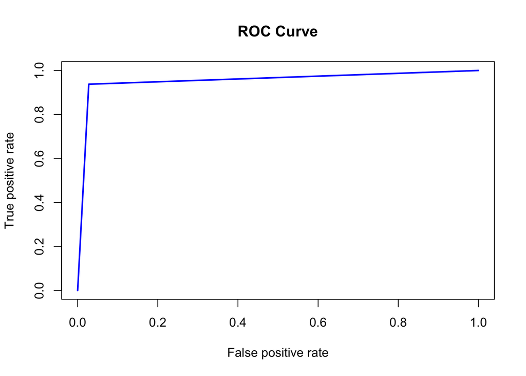

# Decision trees

[output not shown]

[output not shown]

[output not shown]

[output not shown]

[output not shown]

[output not shown]

[output not shown]

[output not shown]

[output not shown]

[output not shown]

[output not shown]

```
## # A tibble: 2 × 6
##   .metric  .estimator  mean     n std_err .config
##   <chr>    <chr>      <dbl> <int>   <dbl> <chr>
## 1 accuracy binary     0.919    10  0.0138 Preprocessor1_Model1
## 2 roc_auc  binary     0.931    10  0.0154 Preprocessor1_Model1
```

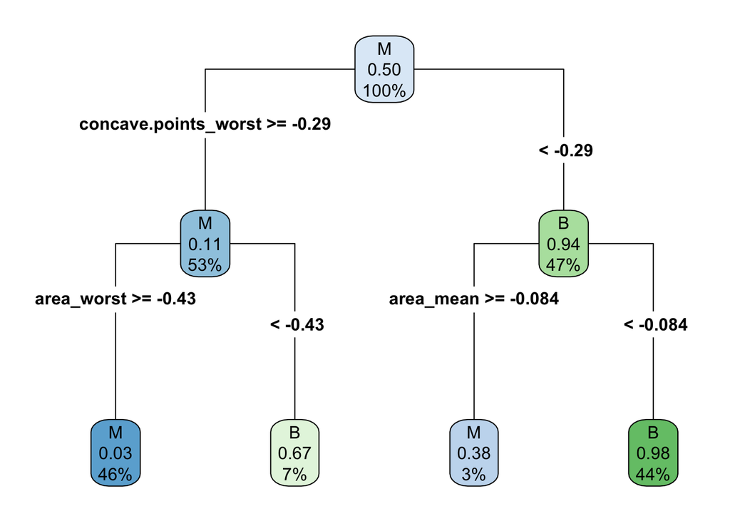

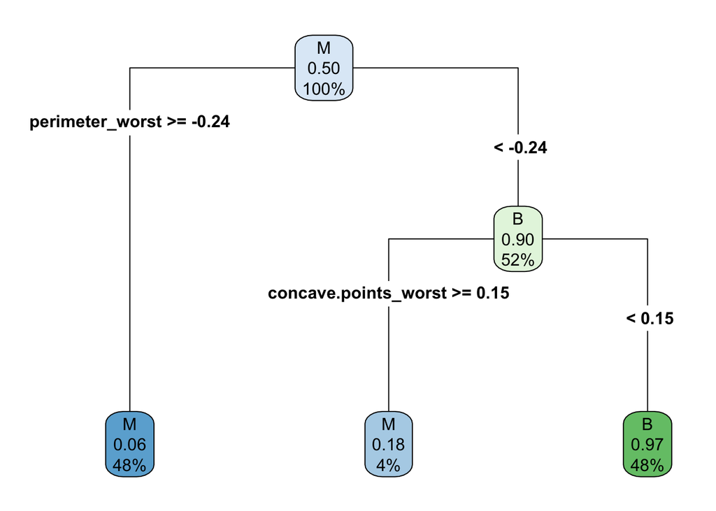

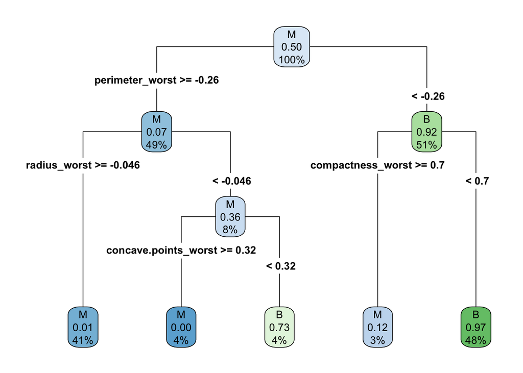

- The accuracy and the AUC is calculated for the evaluation of this initial model.

[output not shown]

[output not shown]

[output not shown]

[output not shown]

[output not shown]

[output not shown]

[output not shown]

[output not shown]

[output not shown]

[output not shown]

```
## # A tibble: 5 × 8
##   cost_complexity min_n .metric .estimator  mean     n std_err .config
##             <dbl> <int> <chr>   <chr>      <dbl> <int>   <dbl> <chr>
## 1    0.0000000001    21 roc_auc binary     0.937    10  0.0135 Preprocessor1_Mo…
## 2    0.000000001     21 roc_auc binary     0.937    10  0.0135 Preprocessor1_Mo…
## 3    0.00000001      21 roc_auc binary     0.937    10  0.0135 Preprocessor1_Mo…
## 4    0.0000001       21 roc_auc binary     0.937    10  0.0135 Preprocessor1_Mo…
## 5    0.000001        21 roc_auc binary     0.937    10  0.0135 Preprocessor1_Mo…
```

- Wee see that the best models have the same value for the roc AUC metric and min_n, so we choose the one with less cost complexity.

[output not shown]

[output not shown]

[output not shown]

[output not shown]

[output not shown]

[output not shown]

[output not shown]

[output not shown]

[output not shown]

[output not shown]

```
## Decision Tree Model Specification (classification)
##
## Main Arguments:
##   cost_complexity = 1e-10
##   min_n = 21
##
## Computational engine: rpart
```

[output not shown]

```
## # A tibble: 2 × 4
##   .metric  .estimator .estimate .config
##   <chr>    <chr>          <dbl> <chr>
## 1 accuracy binary         0.924 Preprocessor1_Model1
## 2 roc_auc  binary         0.957 Preprocessor1_Model1
```

- As expected, the evaluation shows now a better model. Now we plot again the ROC curve.

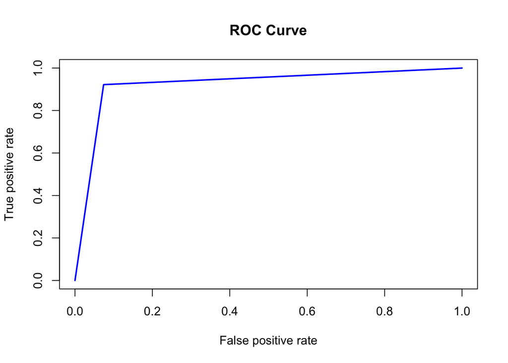

# Random forest

```
## parsnip model object
##
## Ranger result
##
## Call:
##  ranger::ranger(x = maybe_data_frame(x), y = y, num.threads = 1,      verbose = FALSE, seed = sample.int(10^5, 1), probability = TRUE)
##
## Type:                             Probability estimation
## Number of trees:                  500
## Sample size:                      296
## Number of independent variables:  30
## Mtry:                             5
## Target node size:                 10
## Variable importance mode:         none
## Splitrule:                        gini
## OOB prediction error (Brier s.):  0.03967722
```

```
## # A tibble: 2 × 3
##   .metric  .estimator .estimate
##   <chr>    <chr>          <dbl>
## 1 accuracy binary         0.936
## 2 kap      binary         0.866
```

[output not shown]

[output not shown]

[output not shown]

[output not shown]

[output not shown]

[output not shown]

[output not shown]

[output not shown]

[output not shown]

[output not shown]

```
## # A tibble: 3 × 7
##    mtry .metric .estimator  mean     n std_err .config
##   <dbl> <chr>   <chr>      <dbl> <int>   <dbl> <chr>
## 1     5 roc_auc binary     0.986    10 0.00767 Preprocessor1_Model3
## 2     4 roc_auc binary     0.986    10 0.00718 Preprocessor1_Model2
## 3     3 roc_auc binary     0.986    10 0.00784 Preprocessor1_Model1
```

```
## Random Forest Model Specification (classification)
##
## Main Arguments:
##   mtry = 4
##
## Engine-Specific Arguments:
##   importance = impurity
##
## Computational engine: ranger
```

[output not shown]

[output not shown]

[output not shown]

[output not shown]

[output not shown]

[output not shown]

[output not shown]

[output not shown]

[output not shown]

[output not shown]

[output not shown]

```
## # A tibble: 3 × 6
##   .metric  .estimator  mean     n std_err .config
##   <chr>    <chr>      <dbl> <int>   <dbl> <chr>
## 1 accuracy binary     0.955    10 0.00814 Preprocessor1_Model1
## 2 kap      binary     0.896    10 0.0225  Preprocessor1_Model1
## 3 roc_auc  binary     0.986    10 0.00755 Preprocessor1_Model1
```

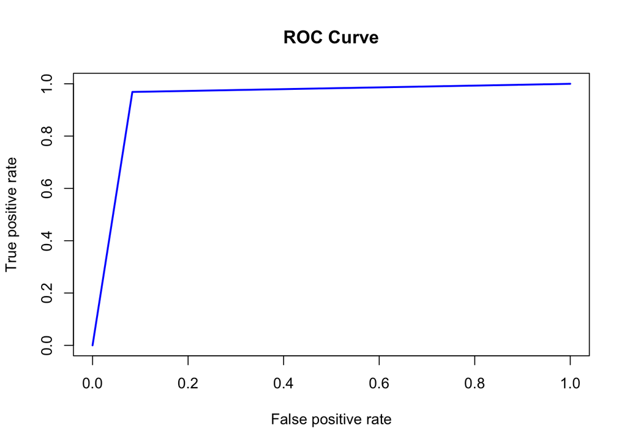

# Logistic regression

```
## # A tibble: 31 × 5
##    term                estimate std.error statistic p.value
##    <chr>                  <dbl>     <dbl>     <dbl>   <dbl>
##  1 (Intercept)           -260.     27705. -0.00938    0.993
##  2 radius_mean           1304.    740076.  0.00176    0.999
##  3 texture_mean           -83.8    16265. -0.00515    0.996
##  4 perimeter_mean        -848.    605786. -0.00140    0.999
##  5 area_mean             -242.    280272. -0.000864   0.999
##  6 smoothness_mean         38.1    29793.  0.00128    0.999
##  7 compactness_mean       130.     76903.  0.00169    0.999
##  8 concavity_mean         207.     90481.  0.00228    0.998
##  9 concave.points_mean   -448.     83212. -0.00538    0.996
## 10 symmetry_mean           43.2    15360.  0.00281    0.998
## # … with 21 more rows
```

```
## [1] 0.007263219
```

```
## 31 x 1 sparse Matrix of class "dgCMatrix"
##                                    s0
## (Intercept)              1.2674905244
## radius_mean              .
## texture_mean             .
## perimeter_mean           .
## area_mean                .
## smoothness_mean          .
## compactness_mean         .
## concavity_mean           .
## concave.points_mean      .
## symmetry_mean            .
## fractal_dimension_mean   .
## radius_se                1.6401896043
## texture_se               .
## perimeter_se             .
## area_se                  .
## smoothness_se            .
## compactness_se          -0.0009004508
## concavity_se             .
## concave.points_se        .
## symmetry_se              .
## fractal_dimension_se    -0.0733286337
## radius_worst             3.0300909341
## texture_worst            0.9659457472
## perimeter_worst          .
## area_worst               .
## smoothness_worst         0.1578808075
## compactness_worst        .
## concavity_worst          0.1910310973
## concave.points_worst     1.5673685416
## symmetry_worst           0.5352197958
## fractal_dimension_worst  .
```

```
## [1] 0.9709302
```

- We see a really good accuracy here in this model. Let’s plot the ROC curve

```
## [1] 0.9986979
```

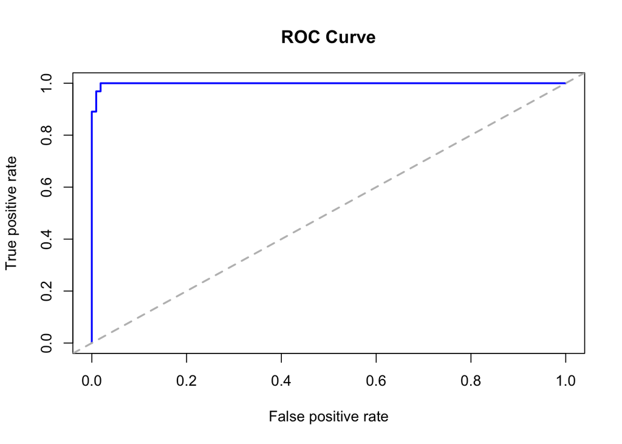

# Exercise 3

Use [The Cancer Genome Atlas (TCGA)](https://www.genome.gov/Funded-Programs-Projects/Cancer-Genome-Atlas) gene expression data of two different cancer types to build a machine learning model that identifies whether one unknown sample belongs to one or the other. The TCGA is a comprehensive and coordinated effort to accelerate our understanding of the molecular basis of cancer through the application of genome analysis technologies, including large-scale genome sequencing. The program has generated, analyzed, and made available genomic sequence, expression, methylation, and copy number variation data on over 11,000 individuals who represent over 30 different types of cancer. After building your model, you should predict the cancer types for 10 unkwnon samples.

For this task, you should retrieve the TCGA data from the [Genomic Data Commons Data Portal](https://portal.gdc.cancer.gov/). If necessary you can watch the video uploaded in the Campus Global. The video assumes that you have previously installed the [GDC data transfer tool](https://gdc.cancer.gov/access-data/gdc-data-transfer-tool).

Each team will work with two specific cancer types, that will be assigned in class.

Important notice: if you do not have a lot of hard drive space in your laptop, you can modify the manifest file to download only 50 samples per cancer types. As part of the assignment, you should provide the input data fed to the machine learning algorithm as a tsv file.

- In this first part, we’ve prepared the TCGA data of both cancer types. We’ve used 50 samples of both cancer types, since the usage of more requires more computational power and storage. Further, we’ve deleted 5 rows that were not out of use for the analysis and training the model and assigned the correct rownames as genes. The same was done for both cancer types.

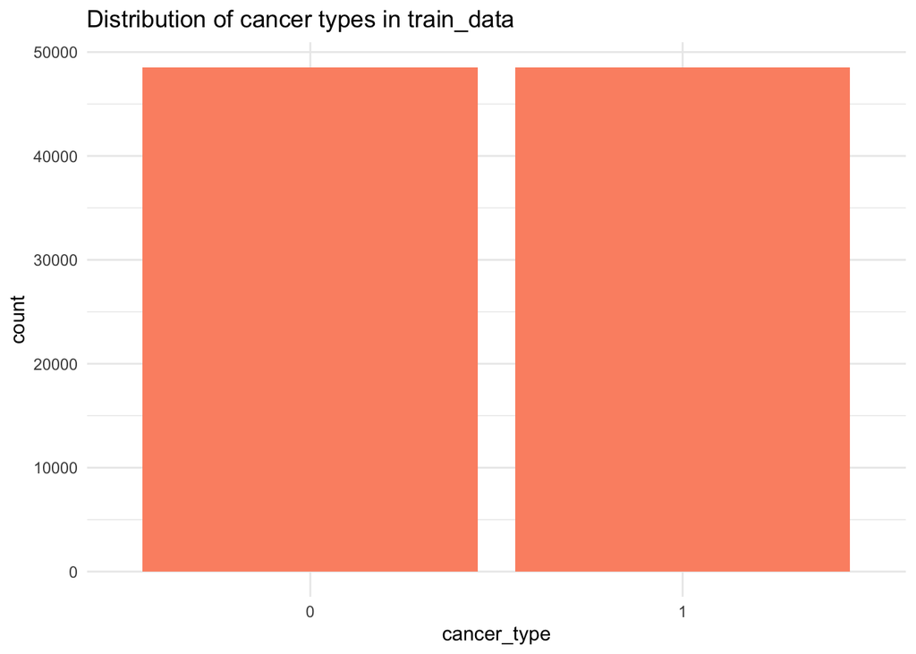

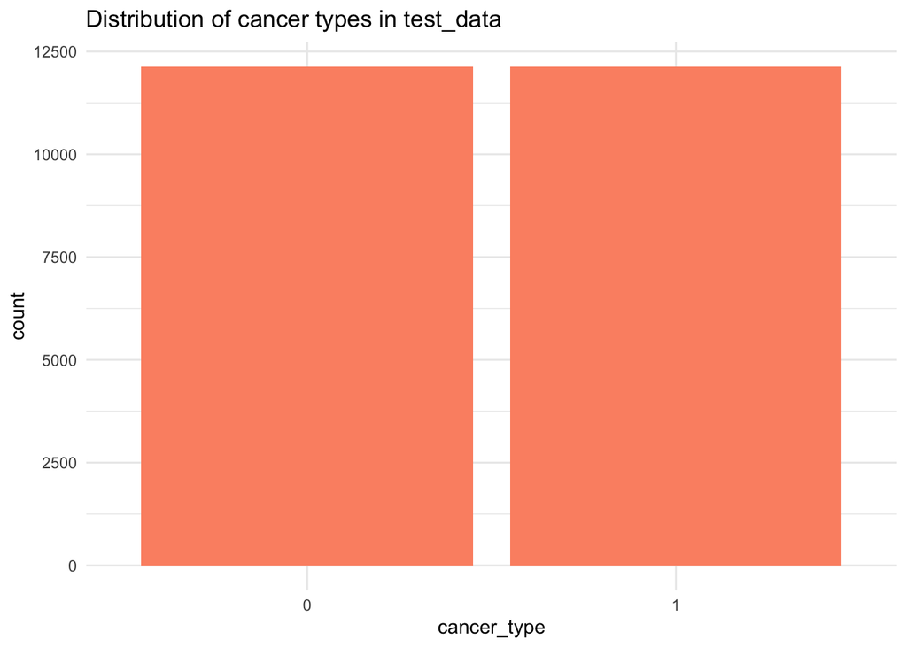

```
##
## Call:
## glm(formula = cancer_type ~ ., family = binomial(), data = train_data)
##
## Deviance Residuals:
##    Min      1Q  Median      3Q     Max
##  -8.49    0.00    0.00    8.49    8.49
##
## Coefficients:
##                      Estimate Std. Error    z value Pr(>|z|)
## (Intercept)        -1.926e+15  2.183e+05 -8.823e+09   <2e-16 ***
## unstranded         -1.555e+11  2.468e+02 -6.303e+08   <2e-16 ***
## stranded_first     -1.282e+12  1.489e+03 -8.614e+08   <2e-16 ***
## stranded_second     1.796e+12  1.485e+03  1.210e+09   <2e-16 ***
## tpm_unstranded      2.178e+12  1.050e+04  2.073e+08   <2e-16 ***
## fpkm_unstranded    -2.240e+14  2.177e+05 -1.029e+09   <2e-16 ***
## fpkm_uq_unstranded  2.089e+14  2.365e+05  8.832e+08   <2e-16 ***
## ---
## Signif. codes:  0 '***' 0.001 '**' 0.01 '*' 0.05 '.' 0.1 ' ' 1
##
## (Dispersion parameter for binomial family taken to be 1)
##
##     Null deviance:  134548  on 97055  degrees of freedom
## Residual deviance: 3479726  on 97049  degrees of freedom
## AIC: 3479740
##
## Number of Fisher Scoring iterations: 25
```

- In the next part, we’ve merged two data frames, so that we could get one data frame with the data containing both cancer types. As columns, we perserved same variables, but then added a new one which would indicate what cancer type the sample gene refers to. The column we added is “cancer_type” and it has the value of 0 for LAML and the vaule of 1 for LGG. The data was centered and scaled before being divided into train and test data.

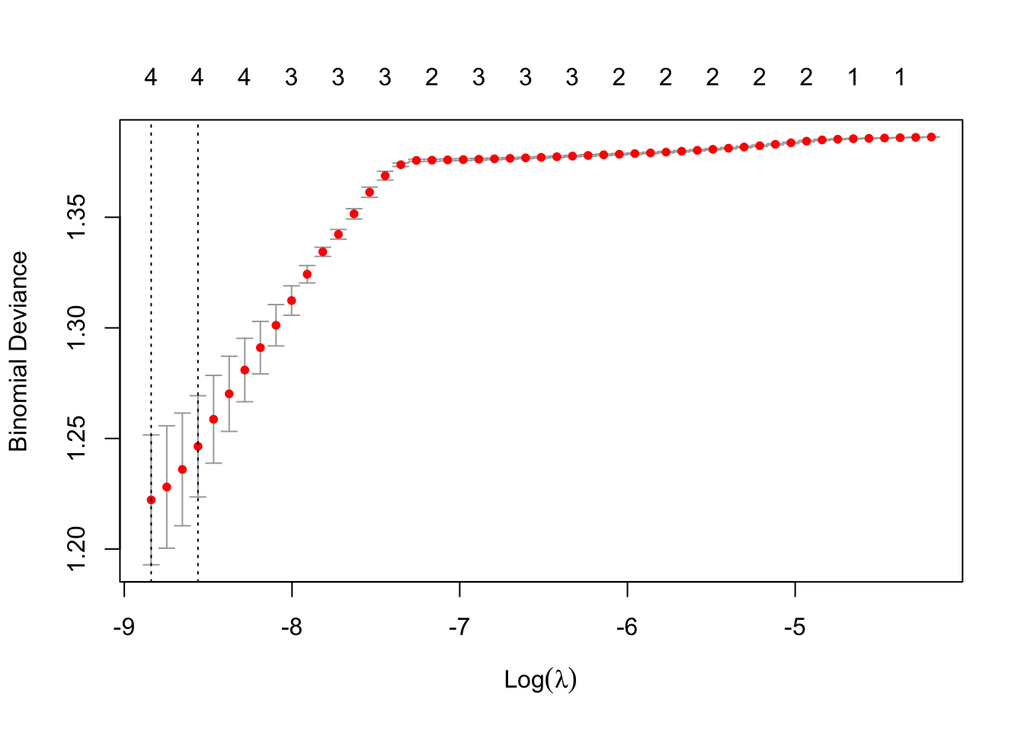

[output not shown]

```
## [1]   -0.2972946    0.7204159    1.4437772  170.0420647 -192.8210179
```

- Here we’ve decided to use Lasso regression which is a type of linear regression that performs variable selection and regularization. It is commonly used in machine learning for feature selection, which can help improve the performance of a model and reduce overfitting. In our example, Lasso regression is used to build a predictive model for cancer type classification. The “glmnet” package is used to perform the Lasso regression, which is followed by splitting the data into training and test sets. The training set is used to fit the model, while the test set is used to evaluate the model’s performance on unseen data.

```
## Area under the curve: 0.9696
```

- We have obtained the AUC value of ~ 0.97 which we considered a good and reliable.

```
## predicted_1
##  laml   lgg
## 53778  6882
```

```
## predicted_2
##  laml   lgg
## 52631  8029
```

```
## predicted_3
##  laml   lgg
## 53736  6924
```

```
## predicted_4
##  laml   lgg
## 52431  8229
```

```
## predicted_5
##  laml   lgg
## 53898  6762
```

```
## predicted_6
##  laml   lgg
## 53468  7192
```

```
## predicted_7
##  laml   lgg
## 53573  7087
```

```
## predicted_8
##  laml   lgg
## 53997  6663
```

```
## predicted_9
##  laml   lgg
## 53704  6956
```

```
## predicted_10
##  laml   lgg
## 53915  6745
```

- Our model predicted more LAML than LGG cancer type predictions in each individual’s case, meaning that LAML was a predicted cancer type for all individuals. This seems to be suspicious, even though we’ve obtained a high AUC value. This would suggest that data processing or merging data into one data frame for training the model had some errors.

```
##    y_pred
##         0     1
##   0 10726  1406
##   1   384 11748
```

```
##           Predicted_Class
## Individual     0     1
##         1  53417  7243
##         2  53652  7008
##         3  53460  7200
##         4  53637  7023
##         5  53417  7243
##         6  53473  7187
##         7  53510  7150
##         8  53776  6884
##         9  53353  7307
##         10 53579  7081
```

- Again, it seems that every individual has been diagnosed with cancer type 0 which is in this case LAML, and it was the same result we obtained by performing the regression model.

# session info

R version 4.2.1 (2022-06-23) Platform: x86_64-apple-darwin17.0 (64-bit) Running under: macOS Big Sur … 10.16

Matrix products: default BLAS: /Library/Frameworks/R.framework/Versions/4.2/Resources/lib/libRblas.0.dylib LAPACK: /Library/Frameworks/R.framework/Versions/4.2/Resources/lib/libRlapack.dylib

locale: [1] en_GB.UTF-8/en_GB.UTF-8/en_GB.UTF-8/C/en_GB.UTF-8/en_GB.UTF-8

attached base packages: [1] stats graphics grDevices utils datasets methods base

other attached packages: [1] randomForest_4.7-1.1 pROC_1.18.0 caret_6.0-93  
[4] lattice_0.20-45 kknn_1.3.1 themis_1.0.0  
[7] glmnet_4.1-6 Matrix_1.5-3 ranger_0.14.1  
[10] rpart.plot_3.1.1 rpart_4.1.19 ROCR_1.0-11  
[13] yardstick_1.1.0 workflowsets_1.0.0 workflows_1.1.2  
[16] tune_1.0.1 rsample_1.1.1 recipes_1.0.4  
[19] parsnip_1.0.3 modeldata_1.1.0 infer_1.0.4  
[22] dials_1.1.0 scales_1.2.1 broom_1.0.3  
[25] tidymodels_1.0.0 forcats_1.0.0 stringr_1.5.0  
[28] dplyr_1.1.0 purrr_1.0.1 readr_2.1.4  
[31] tidyr_1.3.0 tibble_3.1.8 ggplot2_3.4.1  
[34] tidyverse_1.3.2 caTools_1.18.2 leaps_3.1

loaded via a namespace (and not attached): [1] googledrive_2.0.0 colorspace_2.1-0 ellipsis_0.3.2  
[4] class_7.3-21 fs_1.6.1 rstudioapi_0.14  
[7] farver_2.1.1 listenv_0.9.0 furrr_0.3.1  
[10] prodlim_2019.11.13 fansi_1.0.4 lubridate_1.9.2  
[13] xml2_1.3.3 codetools_0.2-19 splines_4.2.1  
[16] cachem_1.0.6 knitr_1.42 jsonlite_1.8.4  
[19] dbplyr_2.3.0 compiler_4.2.1 httr_1.4.4  
[22] backports_1.4.1 assertthat_0.2.1 fastmap_1.1.0  
[25] gargle_1.3.0 cli_3.6.0 htmltools_0.5.4  
[28] tools_4.2.1 igraph_1.4.0 gtable_0.3.1  
[31] glue_1.6.2 reshape2_1.4.4 Rcpp_1.0.10  
[34] cellranger_1.1.0 jquerylib_0.1.4 DiceDesign_1.9  
[37] vctrs_0.5.2 nlme_3.1-162 iterators_1.0.14  
[40] timeDate_4022.108 gower_1.0.1 xfun_0.37  
[43] globals_0.16.2 rvest_1.0.3 timechange_0.2.0  
[46] lifecycle_1.0.3 googlesheets4_1.0.1 future_1.31.0  
[49] MASS_7.3-58.2 ipred_0.9-13 hms_1.1.2  
[52] parallel_4.2.1 yaml_2.3.7 sass_0.4.5  
[55] stringi_1.7.12 highr_0.10 foreach_1.5.2  
[58] lhs_1.1.6 hardhat_1.2.0 shape_1.4.6  
[61] lava_1.7.1 rlang_1.0.6 pkgconfig_2.0.3  
[64] bitops_1.0-7 evaluate_0.20 labeling_0.4.2  
[67] tidyselect_1.2.0 parallelly_1.34.0 plyr_1.8.8  
[70] magrittr_2.0.3 R6_2.5.1 generics_0.1.3  
[73] DBI_1.1.3 pillar_1.8.1 haven_2.5.1  
[76] withr_2.5.0 survival_3.5-3 nnet_7.3-18  
[79] ROSE_0.0-4 future.apply_1.10.0 modelr_0.1.10  
[82] crayon_1.5.2 utf8_1.2.3 tzdb_0.3.0  
[85] rmarkdown_2.20 grid_4.2.1 readxl_1.4.2  
[88] data.table_1.14.6 ModelMetrics_1.2.2.2 reprex_2.0.2  
[91] digest_0.6.31 stats4_4.2.1 munsell_0.5.0  
[94] GPfit_1.0-8 bslib_0.4.2